# Factors Affecting Bikeshare Trip Duration

#### Dataset Overview

> This data set includes information about individual rides made in a bike-sharing system covering the greater San Francisco Bay area for one month; starting from February 1 and end on March 1 of year 2019.  
> This dataset is taken from https://www.fordgobike.com/system-data

#### Dataset Features

> It consists of 183412 resords and it has 16 features, the most important of which is: information about trips taken by service's members, users types, users age and gender, stations of starting and ending trips, duration of trips and so on.

#### Distribution of Duration(sec)

The histogram shows that the data is highly skewed to the right so a log scale is used to further explore the duration data

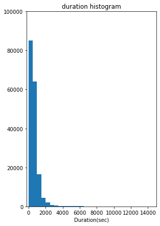

**Plotting the duration on a logscale produces a histogram that looks roughly unimodal. Most of the data points appear to be less than 1000 seconds. The peak is at about 500 seconds and the average duration is 700 seconds**

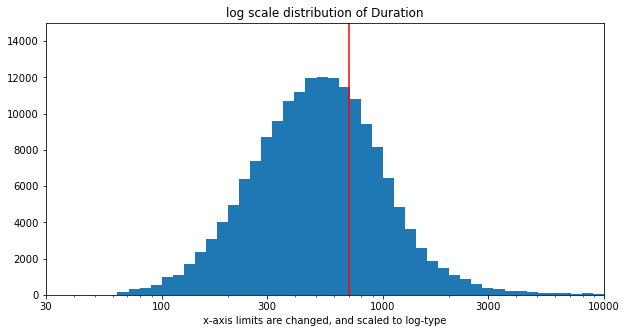

### Age and Trip Duration

In plotting age against trip duration, it's shown that most riders age is between 20 and 60 years old and duration is less than 7000 seconds, or around 116 minutes

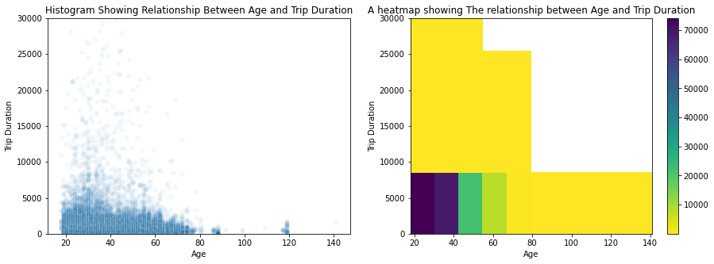

### Weekdays and Trip Duration

Saturdays and Sundays tend to have higher trip duration.

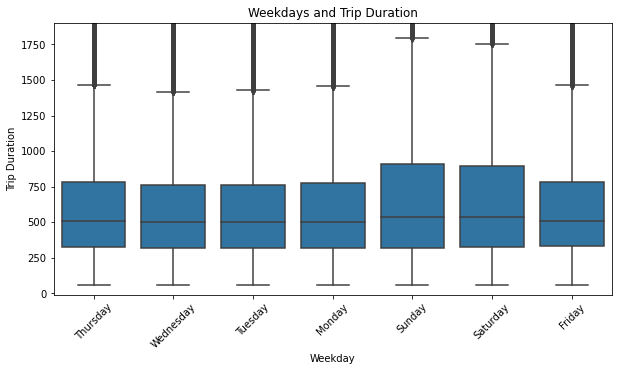

### Genders and Trip Duration

"Other" gender types have the largest average trip duration followed by females followed by males. This is interesting as male riders surpass females and other riders

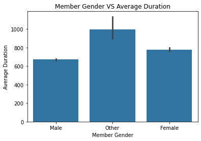

## User Types

By comparing trip duration for different user types, we find that customers tend to take longer trips than subscribers

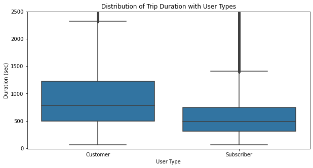

### Age Against Duration for different Genders

By plotting age against duration for different gender types, it's found out that users of "Other' gender who are in their twenties have the largest mean trip duration. And surprisingly the second highest trip duration is by people in their fifties

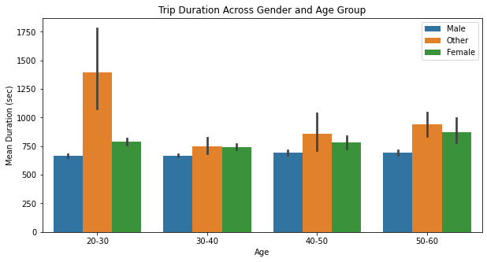

## Mean Trip Duration for Different User Types Across The Week

On average, customers take longer trip durations than Subscribers, especially on Saturday and Sunday

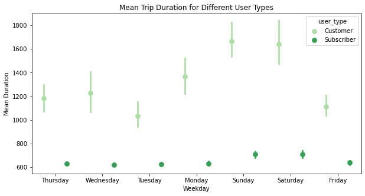

## Mean Duration Against The Start Time

Longer durations occured for trips started at 12 or 2 or 3 AM and were majorly by "Other" gender

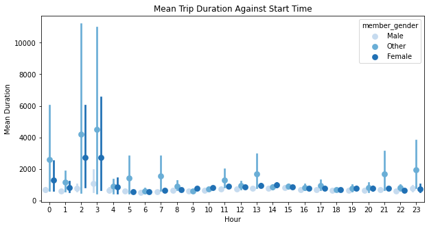